# Case Study 1: Breweries & Beer Information

Noelle Brown & Ann Nelson

October 15, 2017

# Introduction:

*This study is marketing research for the Greenbrier Valley Brewing Company, West Virginia, who* *is interested in expanding into a new territory. We will be determining the best location for* *extending their expertise into a new terroritory.*

*Import the data sets*

```r
Beers <- read.csv("~/Documents/Git/CaseStudy1/Beers.csv")
Breweries <- read.csv("~/Documents/Git/CaseStudy1/Breweries.csv")
```

**Breweries present in each state:**

*Use the summary function on the State column of the Brewery dataset to produce a report of the number of breweries/state*

```r
summary(Breweries$State)
```

```
##  AK  AL  AR  AZ  CA  CO  CT  DC  DE  FL  GA  HI  IA  ID  IL  IN  KS  KY
##   7   3   2  11  39  47   8   1   2  15   7   4   5   5  18  22   3   4
##  LA  MA  MD  ME  MI  MN  MO  MS  MT  NC  ND  NE  NH  NJ  NM  NV  NY  OH
##   5  23   7   9  32  12   9   2   9  19   1   5   3   3   4   2  16  15
##  OK  OR  PA  RI  SC  SD  TN  TX  UT  VA  VT  WA  WI  WV  WY
##   6  29  25   5   4   1   3  28   4  16  10  23  20   1   4
```

**First 6 observations and the last six observations of the merged beer and breweries data:**

*Merge the data sets and rename column names to make readable, and facilitate the merge* *Column used to merge the two datasets together is Brewery_id* *Validate the merge and tidiness of the merged data set* *Write the merged dataset to an output csv file*

```r
names(Breweries)[names(Breweries) == 'Brew_ID'] <- 'Brewery_id'

BeersBreweries <- merge(Beers, Breweries, by='Brewery_id')

names(BeersBreweries)[names(BeersBreweries) == 'Name.x'] <- 'Beer_Name'
names(BeersBreweries)[names(BeersBreweries) == 'Name.y'] <- 'Brewery_Name'

str(BeersBreweries)
```

```
## 'data.frame':    2410 obs. of  10 variables:
##  $ Brewery_id  : int  1 1 1 1 1 1 2 2 2 2 ...
##  $ Beer_Name   : Factor w/ 2305 levels "#001 Golden Amber Lager",..: 802 1258 2185 1640 1926 1525 458 1218 43 71 ...
##  $ Beer_ID     : int  2692 2691 2690 2689 2688 2687 2686 2685 2684 2683 ...
##  $ ABV         : num  0.045 0.049 0.048 0.06 0.06 0.056 0.08 0.125 0.077 0.042 ...
##  $ IBU         : int  50 26 19 38 25 47 68 80 25 42 ...
##  $ Style       : Factor w/ 100 levels "","Abbey Single Ale",..: 16 77 48 83 22 57 12 46 77 18 ...
##  $ Ounces      : num  16 16 16 16 16 16 16 16 16 16 ...
##  $ Brewery_Name: Factor w/ 551 levels "10 Barrel Brewing Company",..: 355 355 355 355 355 355 12 12 12 12 ...
##  $ City        : Factor w/ 384 levels "Abingdon","Abita Springs",..: 228 228 228 228 228 228 200 200 200 200 ...
##  $ State       : Factor w/ 51 levels " AK"," AL"," AR",..: 24 24 24 24 24 24 18 18 18 18 ...
```

```r
head(BeersBreweries)
```

```
##   Brewery_id     Beer_Name Beer_ID   ABV IBU
## 1          1  Get Together    2692 0.045  50
## 2          1 Maggie's Leap    2691 0.049  26
## 3          1    Wall's End    2690 0.048  19
## 4          1       Pumpion    2689 0.060  38
## 5          1    Stronghold    2688 0.060  25
## 6          1   Parapet ESB    2687 0.056  47
##                                 Style Ounces       Brewery_Name
## 1                        American IPA     16 NorthGate Brewing
## 2                  Milk / Sweet Stout     16 NorthGate Brewing
## 3                   English Brown Ale     16 NorthGate Brewing
## 4                         Pumpkin Ale     16 NorthGate Brewing
## 5                     American Porter     16 NorthGate Brewing
## 6 Extra Special / Strong Bitter (ESB)     16 NorthGate Brewing
##          City State
## 1 Minneapolis    MN
## 2 Minneapolis    MN
## 3 Minneapolis    MN
## 4 Minneapolis    MN
## 5 Minneapolis    MN
## 6 Minneapolis    MN
```

```r
tail(BeersBreweries)
```

```
##      Brewery_id                 Beer_Name Beer_ID   ABV IBU
## 2405        556             Pilsner Ukiah      98 0.055  NA
## 2406        557  Heinnieweisse Weissebier      52 0.049  NA
## 2407        557           Snapperhead IPA      51 0.068  NA
## 2408        557         Moo Thunder Stout      50 0.049  NA
## 2409        557         Porkslap Pale Ale      49 0.043  NA
## 2410        558 Urban Wilderness Pale Ale      30 0.049  NA
##                        Style Ounces                  Brewery_Name
## 2405         German Pilsener     12         Ukiah Brewing Company
## 2406              Hefeweizen     12       Butternuts Beer and Ale
## 2407            American IPA     12       Butternuts Beer and Ale
## 2408      Milk / Sweet Stout     12       Butternuts Beer and Ale
## 2409 American Pale Ale (APA)     12       Butternuts Beer and Ale
## 2410        English Pale Ale     12 Sleeping Lady Brewing Company
##               City State
## 2405         Ukiah    CA
## 2406 Garrattsville    NY
## 2407 Garrattsville    NY
## 2408 Garrattsville    NY
## 2409 Garrattsville    NY
## 2410     Anchorage    AK
```

```r
write.csv(BeersBreweries,"BeersBreweries.csv")
```

*The merged dataset is tidy having descriptive human readable names.*

**The number of NA’s in each column:**

*Use the sapply function to apply the sum function across the merged data set. The sum function is summing up the count of NA using the is.na funtion on each column*

```r
sapply( BeersBreweries , function( x ) sum( is.na( x ) ) )
```

```
##   Brewery_id    Beer_Name      Beer_ID          ABV          IBU
##            0            0            0           62         1005
##        Style       Ounces Brewery_Name         City        State
##            0            0            0            0            0
```

*Only two columns have NA values, ABV and IBV, with 62 and 1005 occurrances, respectively.*

**Median alcohol content and international bitterness unit for each state:**

*Compute the median alcohol content & international bitterness unit for each state, renames columns for consistency, merges values; plot bar chart of each value.*

```r
medianABVbystate <- aggregate(BeersBreweries$ABV, list(BeersBreweries$State), median, na.rm=TRUE)
names(medianABVbystate)[names(medianABVbystate) == 'Group.1'] <- 'State'
names(medianABVbystate)[names(medianABVbystate) == 'x'] <- 'MedianABV'
medianIBUbystate <- aggregate(BeersBreweries$IBU, list(BeersBreweries$State), median, na.rm=TRUE)
names(medianIBUbystate)[names(medianIBUbystate) == 'Group.1'] <- 'State'
names(medianIBUbystate)[names(medianIBUbystate) == 'x'] <- 'MedianIBU'
medianbystate <- merge(medianABVbystate, medianIBUbystate, by='State')
```

The median ABV and IBU values by state:

```r
medianbystate
```

```
##    State MedianABV MedianIBU
## 1     AK    0.0560      46.0
## 2     AL    0.0600      43.0
## 3     AR    0.0520      39.0
## 4     AZ    0.0550      20.5
## 5     CA    0.0580      42.0
## 6     CO    0.0605      40.0
## 7     CT    0.0600      29.0
## 8     DC    0.0625      47.5
## 9     DE    0.0550      52.0
## 10    FL    0.0570      55.0
## 11    GA    0.0550      55.0
## 12    HI    0.0540      22.5
## 13    IA    0.0555      26.0
## 14    ID    0.0565      39.0
```

[output cut: 37 more lines]

Barplot for median ABV by state:

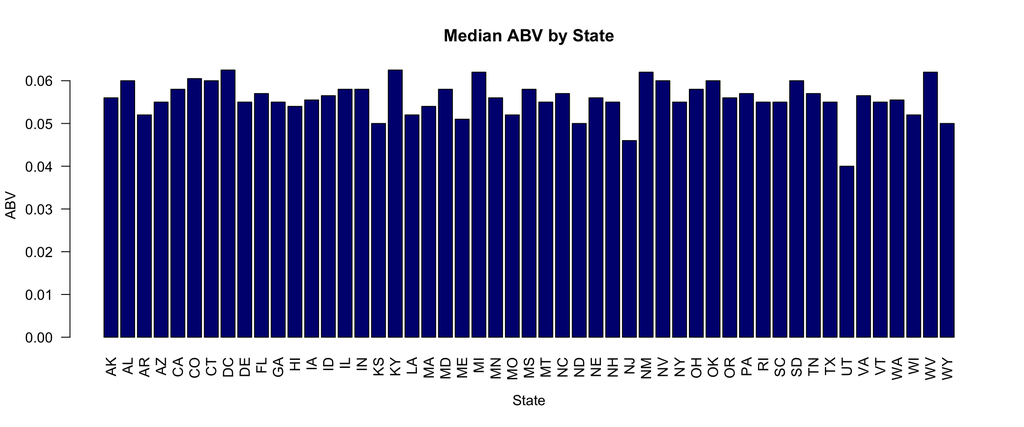

```r
barplot(medianbystate$MedianABV, main="Median ABV by State", xlab="State", ylab="ABV", col="navy", names.arg=medianbystate$State, las=2)
```

Barplot for median IBU by state:

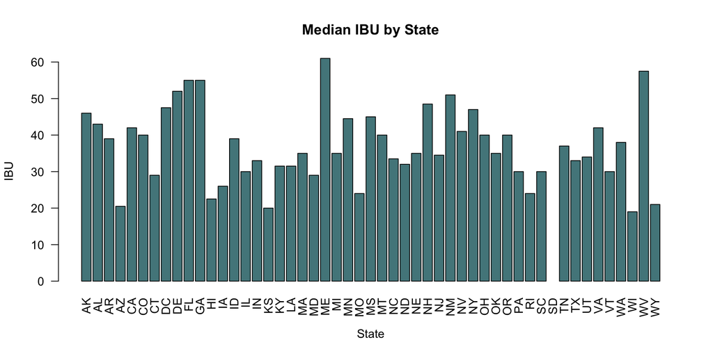

```r
barplot(medianbystate$MedianIBU, main="Median IBU by State", xlab="State", ylab="IBU", col="cadetblue4", names.arg=medianbystate$State, las=2)
```

**The states with the maximum alcoholic (ABV) beer and the most bitter (IBU) beer:**

*Finds the max ABV value from all states, finds state that the value belongs to, prints out just the state with the maximum value.*

```r
maxABV <- max(BeersBreweries$ABV, na.rm=TRUE)
maxABVstate <- BeersBreweries[BeersBreweries$ABV == maxABV, "State"]
maxABVstate <- maxABVstate[!is.na(maxABVstate)]
maxABVstate
```

```
## [1]  CO
## 51 Levels:  AK  AL  AR  AZ  CA  CO  CT  DC  DE  FL  GA  HI  IA  ID ...  WY
```

The state that has the maximum alcoholic (ABV) beer is Colorado (CO).

*Finds the max IBU value from all states, finds state that the value belongs to, prints out just the state with the maximum value.*

```r
maxIBU <- max(BeersBreweries$IBU, na.rm=TRUE)
maxIBUstate <- BeersBreweries[BeersBreweries$IBU == maxIBU, "State"]
maxIBUstate <- maxIBUstate[!is.na(maxIBUstate)]
maxIBUstate
```

```
## [1]  OR
## 51 Levels:  AK  AL  AR  AZ  CA  CO  CT  DC  DE  FL  GA  HI  IA  ID ...  WY
```

The state that has the most bitter (IBU) beer is Oregon (OR).

**Summary statistics for the ABV:**

*Print out summary statistics for ABV*

```r
summary(BeersBreweries$ABV)
```

```
##    Min. 1st Qu.  Median    Mean 3rd Qu.    Max.    NA's
## 0.00100 0.05000 0.05600 0.05977 0.06700 0.12800      62
```

The ABV for all of the beers has a minimum of 0.001, a median of 0.056, and a max of 0.128. The mean ABV is 0.05977.

**Relationship between the bitterness of the beer and its alcoholic content:**

*Create scatterplot of IBU vs. ABV*

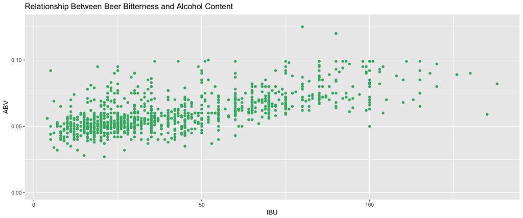

```r
library(ggplot2)
qplot(BeersBreweries$IBU, BeersBreweries$ABV, col=I("mediumseagreen"), main="Relationship Between Beer Bitterness and Alcohol Content", xlab="IBU", ylab="ABV", na.rm=TRUE)
```

There seems to be a slightly positive correlation between the bitterness of the beer (IBU) and its alcoholic content (ABV), as seen in the plot above. We can say that in general, the more bitter the beer is, the higher its alcohol content.

# Conclusion:

The Greenbrier Valley Brewing Company specializes in bitter beer. Their beer recipe has the second highest median bitterness rating (IBU) in the country compared to other states. They are interested in expanding into a new region. Our recommendation is that they extend into Maine. This recommendation is based on the popularity of bitter beer in ME (highest median IBU value), which aligns to the strength of the Greenbrier Valley Brewing Company brand, and the relatively low degree of competition (9 breweries currently exist in ME) compared to other states.